# Linear%20Regression

#### Summary Statistics

```sas
title 'Descriptive Statistics';
ods noproctitle;
Proc means data=pfolio.bodyfat
n nmiss min mean stddev kurt skew p99 max;
var PctBodyFat2	Density	Age	Weight	Height	Adioposity	FatFreeWt
Neck	Chest	Abdomen	Hip	Thigh	Knee	Ankle	Biceps	Forearm	Wrist;
run;
```

Descriptive Statistics

| Variable | Label | N | N Miss | Minimum | Mean | Std Dev | Kurtosis | Skewness | 99th Pctl | Maximum |
| --- | --- | --- | --- | --- | --- | --- | --- | --- | --- | --- |
| PctBodyFat2 Density Age Weight Height Adioposity FatFreeWt Neck Chest Abdomen Hip Thigh Knee Ankle Biceps Forearm Wrist | Percent Body Fat (method 2) gm / cm^3 yrs lbs inches Weight / Height^2 Fat Free Weight (lbs) cm cm cm cm cm cm cm cm cm cm | 252 252 252 252 252 252 252 252 252 252 252 252 252 252 252 252 252 | 0 0 0 0 0 0 0 0 0 0 0 0 0 0 0 0 0 | 0 0.9950000 22.0000000 118.5000000 64.0000000 18.1000000 105.9000000 31.1000000 79.3000000 69.4000000 85.0000000 47.2000000 33.0000000 19.1000000 24.8000000 21.0000000 15.8000000 | 19.1507937 1.0555738 44.8849206 178.9244048 70.3075397 25.4369048 143.7138889 37.9920635 100.8242063 92.5559524 99.9047619 59.4059524 38.5904762 23.1023810 32.2734127 28.6638889 18.2297619 | 8.3687404 0.0190314 12.6020397 29.3891599 2.6095829 3.6481108 18.2316416 2.4309132 8.4304755 10.7830768 7.1640577 5.2499520 2.4118046 1.6948934 3.0212738 2.0206912 0.9335849 | -0.3338114 -0.3096191 -0.4164409 5.2695136 -0.4039182 6.7124851 2.6567261 2.7196151 0.9872822 2.2488238 7.4713521 2.6657145 1.0615359 11.9451944 0.4984983 0.8663094 0.3956775 | 0.1463531 -0.0201757 0.2835211 1.2052629 0.1026216 1.5617023 0.9612186 0.5526199 0.6815557 0.8384179 1.4971273 0.8212096 0.5167440 2.2551343 0.2855300 -0.2193328 0.2816139 | 38.1000000 1.0983000 72.0000000 247.2500000 76.0000000 37.6000000 195.3000000 43.2000000 121.6000000 122.1000000 116.1000000 72.9000000 45.0000000 29.6000000 38.5000000 33.7000000 20.9000000 | 47.5000000 1.1089000 81.0000000 363.1500000 77.7500000 48.9000000 240.5000000 51.2000000 136.2000000 148.1000000 147.7000000 87.3000000 49.1000000 33.9000000 45.0000000 34.9000000 21.4000000 |

1. The above table indicates that there are no missing values
2. Comparing 99th percentile to the maximum value, it can be inferred that weight, adioposity, abdomen, chest, fatfreewt and hip might have some outlier cases, which needs further investigation as they might effect the effectiveness of our model

**Target Variable Distribution**

Descriptive Statistics

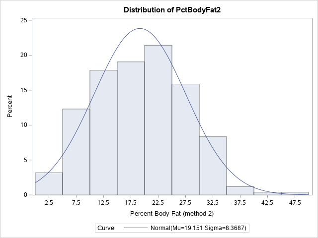

Descriptive Statistics

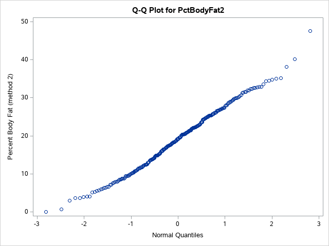

```sas
Ods noproctitle;
Ods select histogram qqplot;
Proc univariate data=pfolio.bodyfat;
var PctBodyFat2;
histogram PctBodyFat2 / normal;
qqplot PctBodyFat2;
run;
```

Visually, histogram look normally distributed and slight positive skewness could be because of the outliers that were noticed above - which needs further investigation

**Outliers Investigation**

```sas
title 'Case 39 is a outlier as it is the heaviest case in the dataset';
proc sort data=pfolio.bodyfat;
by case weight height;
proc print data=pfolio.bodyfat (firstobs=20 obs=40);
var case age height weight;
title;
```

Case 39 is a outlier as it is the heaviest case in the dataset

| Obs | Case | Age | Height | Weight |
| --- | --- | --- | --- | --- |
| 20 | 20 | 33 | 73.50 | 211.75 |
| 21 | 21 | 28 | 68.00 | 179.00 |
| 22 | 22 | 28 | 69.75 | 200.50 |
| 23 | 23 | 31 | 68.25 | 140.25 |
| 24 | 24 | 32 | 70.00 | 148.75 |
| 25 | 25 | 28 | 67.75 | 151.25 |
| 26 | 26 | 27 | 71.50 | 159.25 |
| 27 | 27 | 34 | 67.50 | 131.50 |
| 28 | 28 | 31 | 67.50 | 148.00 |
| 29 | 29 | 27 | 64.75 | 133.25 |
| 30 | 30 | 29 | 69.00 | 160.75 |
| 31 | 31 | 32 | 73.75 | 182.00 |
| 32 | 32 | 29 | 71.25 | 160.25 |
| 33 | 33 | 27 | 71.25 | 168.00 |
| 34 | 34 | 41 | 71.00 | 218.50 |
| 35 | 35 | 41 | 73.50 | 247.25 |
| 36 | 36 | 49 | 65.00 | 191.75 |
| 37 | 37 | 40 | 70.00 | 202.25 |
| 38 | 38 | 50 | 68.25 | 196.75 |
| 39 | 39 | 46 | 72.25 | 363.15 |
| 40 | 40 | 50 | 67.00 | 203.00 |

 Case 39 has the highest weight and other body measurements like abdomen, chest, fatfreeweight and neck which can be connected back to our individual exploration of all these variables where they showed signs of presence of anolmalies

```sas
data bodyfat7;
set pfolio.bodyfat;
new_pctbodyfat2 = 495/Density - 450;
run;
```

```sas
Proc sort data = bodyfat7;
by case;
run;
```

```sas
proc print data = bodyfat7;
where case in (48, 76, 96, 182);
var case PctBodyFat2 new_pctbodyfat2;
run;
```

| Obs | Case | PctBodyFat2 | new_pctbodyfat2 |
| --- | --- | --- | --- |
| 48 | 48 | 5.6 | 14.1350 |
| 76 | 76 | 18.5 | 14.0915 |
| 96 | 96 | 17.4 | 0.3685 |
| 182 | 182 | 0.0 | -3.6117 |

Cases 48, 76, 96, 182 are calculated wrong in the dataset according to Siri body fat percentage formula. This explains the importance of data integrity. Also, according to the Siri Formulla, case 182 has negative pctbodyfat, which is unusal - hence we can consider it as an unsual observation.

#### Histogram for percentage body fat (with right Siri calculations)

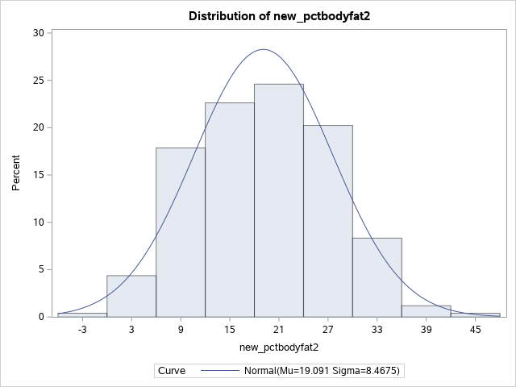

```sas
ods select histogram;
Proc univariate data=bodyfat7;      /* Actual Siri calculation distribuion */
var new_pctbodyfat2 ;
histogram new_pctbodyfat2 / normal;
run;
```

The histogram for the new percentage bodyfat calculation according to Siri formulla visually looks more normally distributed, hence it can be concluded that the abnormal distribution was due to the wrong calculation

### Bi-variate analysis

**FatFreeWeight, Density, PctBodyweight1 can be removed from our analysis as target variable can be mathematically calculated using their formulla. Also, case can be dropped as it doesn't hold any significance**

#### Correlation check

```sas
/* Corrlinearity check  */
ods select  PearsonCorr;
proc corr data=pfolio.bodyfat;
var age weight height adioposity
neck chest abdomen hip thigh knee
ankle biceps forearm wrist;
run;
```

| Pearson Correlation Coefficients, N = 252 Prob > \|r\| under H0: Rho=0 | Pearson Correlation Coefficients, N = 252 Prob > \|r\| under H0: Rho=0 Age | Pearson Correlation Coefficients, N = 252 Prob > \|r\| under H0: Rho=0 Weight | Pearson Correlation Coefficients, N = 252 Prob > \|r\| under H0: Rho=0 Height | Pearson Correlation Coefficients, N = 252 Prob > \|r\| under H0: Rho=0 Adioposity | Pearson Correlation Coefficients, N = 252 Prob > \|r\| under H0: Rho=0 Neck | Pearson Correlation Coefficients, N = 252 Prob > \|r\| under H0: Rho=0 Chest | Pearson Correlation Coefficients, N = 252 Prob > \|r\| under H0: Rho=0 Abdomen | Pearson Correlation Coefficients, N = 252 Prob > \|r\| under H0: Rho=0 Hip | Pearson Correlation Coefficients, N = 252 Prob > \|r\| under H0: Rho=0 Thigh | Pearson Correlation Coefficients, N = 252 Prob > \|r\| under H0: Rho=0 Knee | Pearson Correlation Coefficients, N = 252 Prob > \|r\| under H0: Rho=0 Ankle | Pearson Correlation Coefficients, N = 252 Prob > \|r\| under H0: Rho=0 Biceps | Pearson Correlation Coefficients, N = 252 Prob > \|r\| under H0: Rho=0 Forearm | Pearson Correlation Coefficients, N = 252 Prob > \|r\| under H0: Rho=0 Wrist |
| --- | --- | --- | --- | --- | --- | --- | --- | --- | --- | --- | --- | --- | --- | --- |
| Age yrs | 1.00000 | -0.01275 0.8404 | -0.24521 <.0001 | 0.11885 0.0596 | 0.11351 0.0721 | 0.17645 0.0050 | 0.23041 0.0002 | -0.05033 0.4263 | -0.20010 0.0014 | 0.01752 0.7820 | -0.10506 0.0961 | -0.04116 0.5154 | -0.08506 0.1783 | 0.21353 0.0006 |
| Weight lbs | -0.01275 0.8404 | 1.00000 | 0.48689 <.0001 | 0.88735 <.0001 | 0.83072 <.0001 | 0.89419 <.0001 | 0.88799 <.0001 | 0.94088 <.0001 | 0.86869 <.0001 | 0.85317 <.0001 | 0.61369 <.0001 | 0.80042 <.0001 | 0.63030 <.0001 | 0.72977 <.0001 |
| Height inches | -0.24521 <.0001 | 0.48689 <.0001 | 1.00000 | 0.03977 0.5297 | 0.32114 <.0001 | 0.22683 0.0003 | 0.18977 0.0025 | 0.37211 <.0001 | 0.33856 <.0001 | 0.50050 <.0001 | 0.39313 <.0001 | 0.31851 <.0001 | 0.32203 <.0001 | 0.39778 <.0001 |
| Adioposity Weight / Height^2 | 0.11885 0.0596 | 0.88735 <.0001 | 0.03977 0.5297 | 1.00000 | 0.77786 <.0001 | 0.91180 <.0001 | 0.92388 <.0001 | 0.88327 <.0001 | 0.81271 <.0001 | 0.71366 <.0001 | 0.50032 <.0001 | 0.74638 <.0001 | 0.55859 <.0001 | 0.62591 <.0001 |
| Neck cm | 0.11351 0.0721 | 0.83072 <.0001 | 0.32114 <.0001 | 0.77786 <.0001 | 1.00000 | 0.78484 <.0001 | 0.75408 <.0001 | 0.73496 <.0001 | 0.69570 <.0001 | 0.67240 <.0001 | 0.47789 <.0001 | 0.73115 <.0001 | 0.62366 <.0001 | 0.74483 <.0001 |
| Chest cm | 0.17645 0.0050 | 0.89419 <.0001 | 0.22683 0.0003 | 0.91180 <.0001 | 0.78484 <.0001 | 1.00000 | 0.91583 <.0001 | 0.82942 <.0001 | 0.72986 <.0001 | 0.71950 <.0001 | 0.48299 <.0001 | 0.72791 <.0001 | 0.58017 <.0001 | 0.66016 <.0001 |
| Abdomen cm | 0.23041 0.0002 | 0.88799 <.0001 | 0.18977 0.0025 | 0.92388 <.0001 | 0.75408 <.0001 | 0.91583 <.0001 | 1.00000 | 0.87407 <.0001 | 0.76662 <.0001 | 0.73718 <.0001 | 0.45322 <.0001 | 0.68498 <.0001 | 0.50332 <.0001 | 0.61983 <.0001 |
| Hip cm | -0.05033 0.4263 | 0.94088 <.0001 | 0.37211 <.0001 | 0.88327 <.0001 | 0.73496 <.0001 | 0.82942 <.0001 | 0.87407 <.0001 | 1.00000 | 0.89641 <.0001 | 0.82347 <.0001 | 0.55839 <.0001 | 0.73927 <.0001 | 0.54501 <.0001 | 0.63009 <.0001 |
| Thigh cm | -0.20010 0.0014 | 0.86869 <.0001 | 0.33856 <.0001 | 0.81271 <.0001 | 0.69570 <.0001 | 0.72986 <.0001 | 0.76662 <.0001 | 0.89641 <.0001 | 1.00000 | 0.79917 <.0001 | 0.53980 <.0001 | 0.76148 <.0001 | 0.56684 <.0001 | 0.55868 <.0001 |
| Knee cm | 0.01752 0.7820 | 0.85317 <.0001 | 0.50050 <.0001 | 0.71366 <.0001 | 0.67240 <.0001 | 0.71950 <.0001 | 0.73718 <.0001 | 0.82347 <.0001 | 0.79917 <.0001 | 1.00000 | 0.61161 <.0001 | 0.67871 <.0001 | 0.55590 <.0001 | 0.66451 <.0001 |
| Ankle cm | -0.10506 0.0961 | 0.61369 <.0001 | 0.39313 <.0001 | 0.50032 <.0001 | 0.47789 <.0001 | 0.48299 <.0001 | 0.45322 <.0001 | 0.55839 <.0001 | 0.53980 <.0001 | 0.61161 <.0001 | 1.00000 | 0.48485 <.0001 | 0.41905 <.0001 | 0.56619 <.0001 |
| Biceps cm | -0.04116 0.5154 | 0.80042 <.0001 | 0.31851 <.0001 | 0.74638 <.0001 | 0.73115 <.0001 | 0.72791 <.0001 | 0.68498 <.0001 | 0.73927 <.0001 | 0.76148 <.0001 | 0.67871 <.0001 | 0.48485 <.0001 | 1.00000 | 0.67826 <.0001 | 0.63213 <.0001 |
| Forearm cm | -0.08506 0.1783 | 0.63030 <.0001 | 0.32203 <.0001 | 0.55859 <.0001 | 0.62366 <.0001 | 0.58017 <.0001 | 0.50332 <.0001 | 0.54501 <.0001 | 0.56684 <.0001 | 0.55590 <.0001 | 0.41905 <.0001 | 0.67826 <.0001 | 1.00000 | 0.58559 <.0001 |
| Wrist cm | 0.21353 0.0006 | 0.72977 <.0001 | 0.39778 <.0001 | 0.62591 <.0001 | 0.74483 <.0001 | 0.66016 <.0001 | 0.61983 <.0001 | 0.63009 <.0001 | 0.55868 <.0001 | 0.66451 <.0001 | 0.56619 <.0001 | 0.63213 <.0001 | 0.58559 <.0001 | 1.00000 |

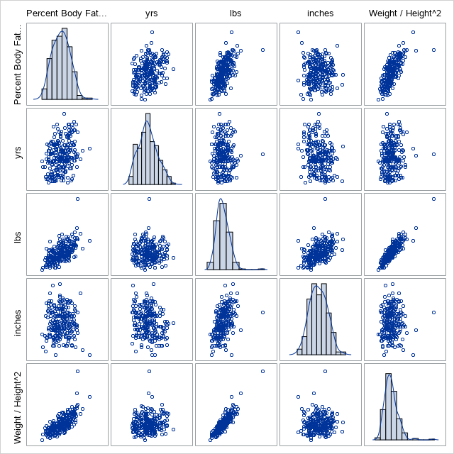

```sas
proc sgscatter data=pfolio.bodyfat;
matrix pctbodyfat2 age weight height
adioposity / diagonal=(histogram kernel);
run;
```

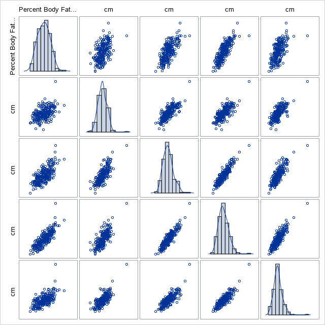

```sas
proc sgscatter data=pfolio.bodyfat;
matrix pctbodyfat2 Neck  Chest  Abdomen Hip/ diagonal=(histogram kernel);
run;
```

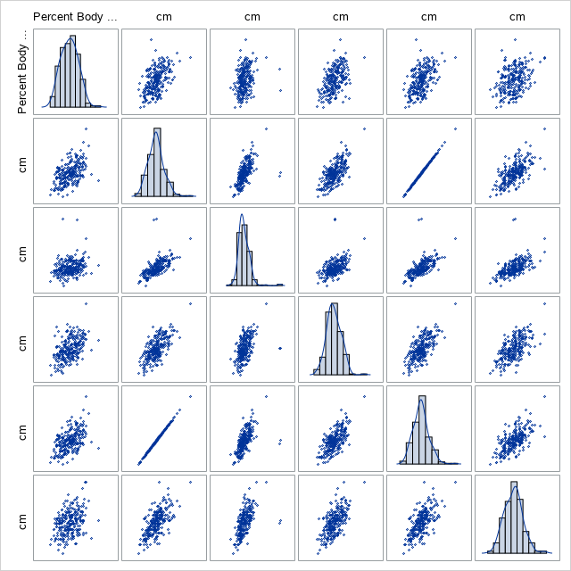

```sas
proc sgscatter data=pfolio.bodyfat;
matrix pctbodyfat2 knee ankle biceps knee wrist / diagonal=(histogram kernel);
run;
```

The above graphs and correaltion table indicates that there are serveral variables in our dataset that have a positive linear relationship with our target variable

### Base Linear Regression Model with all the variables

1. H0 = There is no relatioship target and predictors. Slope = 0 i.e it's a flat line model
2. Ha = There is relationship between the target and predictors i.e. slope is not equal to 0
3. The model must explain relationship between PctbodyFat2 and various body measurements
4. Also, before building a model, it is imperative to build a foundation and make sure there is no multi-collinearity effect. Variation inflation factor (VIF) and eigenvalues can be used to detect any multi-collinearity

```sas
ods select nobs anova fitstatistics parameterestimates collindiag;
proc reg data=pfolio.bodyfat;
model pctbodyfat2 = weight age adioposity height neck
chest abdomen hip thigh knee ankle biceps forearm wrist
/ ss2 influence partial r collin tol vif stb;
run;
quit;
```

Model: MODEL1

Dependent Variable: PctBodyFat2 Percent Body Fat (method 2)

| Number of Observations Read | 252 |
| --- | --- |
| Number of Observations Used | 252 |

| Analysis of Variance Source | Analysis of Variance DF | Analysis of Variance Sum of Squares | Analysis of Variance Mean Square | Analysis of Variance F Value | Analysis of Variance Pr > F |
| --- | --- | --- | --- | --- | --- |
| Model | 14 | 13179 | 941.38231 | 50.71 | <.0001 |
| Error | 237 | 4399.63746 | 18.56387 |  |  |
| Corrected Total | 251 | 17579 |  |  |  |

| Root MSE | 4.30858 | R-Square | 0.7497 |
| --- | --- | --- | --- |
| Dependent Mean | 19.15079 | Adj R-Sq | 0.7349 |
| Coeff Var | 22.49819 |  |  |

| Parameter Estimates Variable | Parameter Estimates Label | Parameter Estimates DF | Parameter Estimates Parameter Estimate | Parameter Estimates Standard Error | Parameter Estimates t Value | Parameter Estimates Pr > \|t\| | Parameter Estimates Type II SS | Parameter Estimates Standardized Estimate | Parameter Estimates Tolerance | Parameter Estimates Variance Inflation |
| --- | --- | --- | --- | --- | --- | --- | --- | --- | --- | --- |
| Intercept | Intercept | 1 | -55.50398 | 39.39467 | -1.41 | 0.1602 | 36.85036 | 0 | . | 0 |
| Weight | lbs | 1 | -0.18974 | 0.10837 | -1.75 | 0.0813 | 56.90523 | -0.66634 | 0.00729 | 137.16039 |
| Age | yrs | 1 | 0.06653 | 0.03224 | 2.06 | 0.0401 | 79.05375 | 0.10019 | 0.44804 | 2.23195 |
| Adioposity | Weight / Height^2 | 1 | 0.83076 | 0.79197 | 1.05 | 0.2953 | 20.42655 | 0.36214 | 0.00886 | 112.86559 |
| Height | inches | 1 | 0.49954 | 0.54805 | 0.91 | 0.3630 | 15.42321 | 0.15577 | 0.03616 | 27.65591 |
| Neck | cm | 1 | -0.47320 | 0.23553 | -2.01 | 0.0457 | 74.93210 | -0.13745 | 0.22562 | 4.43230 |
| Chest | cm | 1 | -0.04298 | 0.10609 | -0.41 | 0.6857 | 3.04684 | -0.04330 | 0.09246 | 10.81581 |
| Abdomen | cm | 1 | 0.93390 | 0.09236 | 10.11 | <.0001 | 1897.92744 | 1.20332 | 0.07456 | 13.41155 |
| Hip | cm | 1 | -0.21630 | 0.14715 | -1.47 | 0.1429 | 40.10945 | -0.18516 | 0.06655 | 15.02626 |
| Thigh | cm | 1 | 0.25051 | 0.14615 | 1.71 | 0.0878 | 54.53725 | 0.15715 | 0.12562 | 7.96024 |
| Knee | cm | 1 | 0.02294 | 0.24784 | 0.09 | 0.9263 | 0.15901 | 0.00661 | 0.20699 | 4.83108 |
| Ankle | cm | 1 | 0.14402 | 0.22490 | 0.64 | 0.5226 | 7.61218 | 0.02917 | 0.50901 | 1.96459 |
| Biceps | cm | 1 | 0.17716 | 0.17253 | 1.03 | 0.3055 | 19.57337 | 0.06396 | 0.27219 | 3.67387 |
| Forearm | cm | 1 | 0.42938 | 0.20083 | 2.14 | 0.0335 | 84.85530 | 0.10368 | 0.44908 | 2.22679 |
| Wrist | cm | 1 | -1.66058 | 0.53307 | -3.12 | 0.0021 | 180.14038 | -0.18525 | 0.29861 | 3.34880 |

| Collinearity Diagnostics Number | Collinearity Diagnostics Eigenvalue | Collinearity Diagnostics Condition Index | Collinearity Diagnostics Proportion of Variation Intercept | Collinearity Diagnostics Proportion of Variation Weight | Collinearity Diagnostics Proportion of Variation Age | Collinearity Diagnostics Proportion of Variation Adioposity | Collinearity Diagnostics Proportion of Variation Height | Collinearity Diagnostics Proportion of Variation Neck | Collinearity Diagnostics Proportion of Variation Chest | Collinearity Diagnostics Proportion of Variation Abdomen | Collinearity Diagnostics Proportion of Variation Hip | Collinearity Diagnostics Proportion of Variation Thigh | Collinearity Diagnostics Proportion of Variation Knee | Collinearity Diagnostics Proportion of Variation Ankle | Collinearity Diagnostics Proportion of Variation Biceps | Collinearity Diagnostics Proportion of Variation Forearm | Collinearity Diagnostics Proportion of Variation Wrist |
| --- | --- | --- | --- | --- | --- | --- | --- | --- | --- | --- | --- | --- | --- | --- | --- | --- | --- |
| 1 | 14.88285 | 1.00000 | 2.133505E-7 | 8.523017E-7 | 0.00013741 | 7.971473E-7 | 2.227396E-7 | 0.00000413 | 0.00000288 | 0.00000447 | 0.00000153 | 0.00000437 | 0.00000362 | 0.00001220 | 0.00001060 | 0.00000995 | 0.00000351 |
| 2 | 0.07365 | 14.21506 | 2.356242E-9 | 0.00008474 | 0.40012 | 0.00001629 | 0.00000144 | 0.00001233 | 0.00000713 | 0.00000454 | 0.00003337 | 0.00028773 | 0.00003108 | 0.00021570 | 0.00031315 | 0.00015409 | 1.069268E-8 |
| 3 | 0.02593 | 23.95697 | 0.00027158 | 0.00187 | 0.01171 | 0.00150 | 0.00025520 | 0.00024949 | 0.00021591 | 0.00366 | 3.89099E-9 | 0.00003717 | 0.00039481 | 0.00419 | 0.00004675 | 0.00275 | 0.00112 |
| 4 | 0.00387 | 62.01476 | 0.00000252 | 0.00282 | 0.00114 | 0.00085994 | 0.00038841 | 0.00478 | 0.00042984 | 0.00298 | 0.00176 | 0.00030507 | 0.00842 | 0.16759 | 0.17945 | 0.15049 | 6.623539E-7 |
| 5 | 0.00342 | 65.98744 | 0.00189 | 0.01630 | 0.08071 | 0.00753 | 0.00008992 | 0.00000716 | 0.00677 | 0.02899 | 0.00340 | 0.00724 | 0.00042425 | 0.04786 | 0.07911 | 0.02027 | 0.00204 |
| 6 | 0.00270 | 74.24051 | 0.00003431 | 0.00526 | 0.00112 | 0.01048 | 0.00248 | 0.00086688 | 0.00000572 | 0.00776 | 0.00292 | 0.00625 | 0.00839 | 0.51764 | 0.00324 | 0.01364 | 0.00047265 |
| 7 | 0.00213 | 83.54715 | 0.00001657 | 0.00262 | 0.07655 | 0.00000401 | 0.00015096 | 0.01812 | 0.02536 | 0.00912 | 0.00310 | 0.11124 | 0.00940 | 0.00297 | 0.32762 | 0.20851 | 0.00847 |
| 8 | 0.00154 | 98.44474 | 0.00052529 | 0.00001467 | 0.09545 | 9.50628E-7 | 0.00050524 | 0.08127 | 0.02911 | 0.00012553 | 0.00215 | 0.09705 | 0.04589 | 0.00018999 | 0.17189 | 0.51505 | 0.01791 |
| 9 | 0.00122 | 110.35038 | 0.00022651 | 0.00077012 | 0.01019 | 0.00544 | 0.00129 | 0.24245 | 0.05610 | 0.12794 | 0.00004278 | 0.06572 | 0.00005704 | 0.04642 | 0.16368 | 0.01588 | 0.08538 |
| 10 | 0.00073577 | 142.22360 | 0.00020422 | 0.00046033 | 0.01659 | 0.01830 | 0.00021025 | 0.20890 | 0.06625 | 0.27718 | 0.00129 | 0.09477 | 0.24406 | 0.16141 | 0.00000274 | 0.03041 | 0.12098 |
| 11 | 0.00062936 | 153.77758 | 2.280932E-7 | 1.96809E-7 | 0.03082 | 0.00000214 | 0.00001729 | 0.21174 | 0.14712 | 0.14184 | 0.02992 | 0.00704 | 0.16995 | 0.01246 | 0.00927 | 0.00248 | 0.51881 |
| 12 | 0.00059749 | 157.82628 | 0.00213 | 0.01430 | 0.26727 | 0.00262 | 0.00409 | 0.06185 | 0.05641 | 0.38217 | 0.05457 | 0.06348 | 0.48425 | 0.00093062 | 0.03315 | 0.00981 | 0.04629 |
| 13 | 0.00049719 | 173.01399 | 0.00322 | 0.00218 | 0.00130 | 0.02172 | 0.00108 | 0.03830 | 0.33366 | 0.00616 | 0.13622 | 0.51553 | 0.02354 | 0.00122 | 0.01761 | 0.01330 | 0.18790 |
| 14 | 0.00020608 | 268.73540 | 0.03437 | 0.03574 | 0.00479 | 0.09150 | 0.02727 | 0.11392 | 0.27780 | 0.00147 | 0.76432 | 0.02249 | 0.00488 | 0.03328 | 0.01349 | 0.00555 | 0.00961 |
| 15 | 0.00002034 | 855.39425 | 0.95711 | 0.91758 | 0.00211 | 0.84002 | 0.96217 | 0.01753 | 0.00075734 | 0.01060 | 0.00027045 | 0.00856 | 0.00032313 | 0.00361 | 0.00111 | 0.01169 | 0.00102 |

1. R square - 0.7497
2. Adj R square - 0.7349

```sas
ods select nobs anova fitstatistics parameterestimates collindiag;
proc reg data=pfolio.bodyfat;
model pctbodyfat2 = age height neck
chest abdomen hip thigh knee ankle biceps forearm wrist
/ ss2 influence partial r stb;
run;
quit;
```

Model: MODEL1

Dependent Variable: PctBodyFat2 Percent Body Fat (method 2)

| Number of Observations Read | 252 |
| --- | --- |
| Number of Observations Used | 252 |

| Analysis of Variance Source | Analysis of Variance DF | Analysis of Variance Sum of Squares | Analysis of Variance Mean Square | Analysis of Variance F Value | Analysis of Variance Pr > F |
| --- | --- | --- | --- | --- | --- |
| Model | 12 | 13114 | 1092.81860 | 58.49 | <.0001 |
| Error | 239 | 4465.16664 | 18.68271 |  |  |
| Corrected Total | 251 | 17579 |  |  |  |

| Root MSE | 4.32235 | R-Square | 0.7460 |
| --- | --- | --- | --- |
| Dependent Mean | 19.15079 | Adj R-Sq | 0.7332 |
| Coeff Var | 22.57008 |  |  |

| Parameter Estimates Variable | Parameter Estimates Label | Parameter Estimates DF | Parameter Estimates Parameter Estimate | Parameter Estimates Standard Error | Parameter Estimates t Value | Parameter Estimates Pr > \|t\| | Parameter Estimates Type II SS | Parameter Estimates Standardized Estimate | Parameter Estimates Tolerance |
| --- | --- | --- | --- | --- | --- | --- | --- | --- | --- |
| Intercept | Intercept | 1 | 10.44939 | 8.73019 | 1.20 | 0.2325 | 26.76539 | 0 | . |
| Age | yrs | 1 | 0.07376 | 0.03174 | 2.32 | 0.0210 | 100.87576 | 0.11107 | 0.46514 |
| Height | inches | 1 | -0.22096 | 0.13836 | -1.60 | 0.1116 | 47.64653 | -0.06890 | 0.57093 |
| Neck | cm | 1 | -0.60041 | 0.22217 | -2.70 | 0.0074 | 136.45015 | -0.17440 | 0.25519 |
| Chest | cm | 1 | -0.09400 | 0.09096 | -1.03 | 0.3025 | 19.95219 | -0.09470 | 0.12657 |
| Abdomen | cm | 1 | 0.91038 | 0.08575 | 10.62 | <.0001 | 2105.63003 | 1.17302 | 0.08705 |
| Hip | cm | 1 | -0.30384 | 0.12485 | -2.43 | 0.0157 | 110.64649 | -0.26010 | 0.09304 |
| Thigh | cm | 1 | 0.21896 | 0.14538 | 1.51 | 0.1334 | 42.38060 | 0.13736 | 0.12778 |
| Knee | cm | 1 | -0.02664 | 0.24711 | -0.11 | 0.9142 | 0.21713 | -0.00768 | 0.20956 |
| Ankle | cm | 1 | 0.10706 | 0.21858 | 0.49 | 0.6247 | 4.48208 | 0.02168 | 0.54233 |
| Biceps | cm | 1 | 0.12481 | 0.16901 | 0.74 | 0.4610 | 10.18800 | 0.04506 | 0.28547 |
| Forearm | cm | 1 | 0.45808 | 0.19989 | 2.29 | 0.0228 | 98.11722 | 0.11061 | 0.45624 |
| Wrist | cm | 1 | -1.77201 | 0.52937 | -3.35 | 0.0009 | 209.33793 | -0.19768 | 0.30474 |

#### Backward Selection

```sas
ods graphics on / width = 7.5in height = 6.6in;
ods select nobs anova fitstatistics parameterestimates;
proc reg data=pfolio.bodyfat;
model pctbodyfat2 = age height neck chest abdomen thigh
knee ankle biceps forearm wrist
/ ss2 influence partial r vif stb
selection = backward;
run;
quit;
```

Model: MODEL1

Dependent Variable: PctBodyFat2 Percent Body Fat (method 2)

| Number of Observations Read | 252 |
| --- | --- |
| Number of Observations Used | 252 |

All Variables Entered: R-Square = 0.7397 and C(p) = 12.0000

| Analysis of Variance Source | Analysis of Variance DF | Analysis of Variance Sum of Squares | Analysis of Variance Mean Square | Analysis of Variance F Value | Analysis of Variance Pr > F |
| --- | --- | --- | --- | --- | --- |
| Model | 11 | 13003 | 1182.10697 | 62.00 | <.0001 |
| Error | 240 | 4575.81313 | 19.06589 |  |  |
| Corrected Total | 251 | 17579 |  |  |  |

Variable Ankle Removed: R-Square = 0.7396 and C(p) = 10.1316

| Analysis of Variance Source | Analysis of Variance DF | Analysis of Variance Sum of Squares | Analysis of Variance Mean Square | Analysis of Variance F Value | Analysis of Variance Pr > F |
| --- | --- | --- | --- | --- | --- |
| Model | 10 | 13001 | 1300.06677 | 68.43 | <.0001 |
| Error | 241 | 4578.32212 | 18.99719 |  |  |
| Corrected Total | 251 | 17579 |  |  |  |

Variable Knee Removed: R-Square = 0.7394 and C(p) = 8.2840

| Analysis of Variance Source | Analysis of Variance DF | Analysis of Variance Sum of Squares | Analysis of Variance Mean Square | Analysis of Variance F Value | Analysis of Variance Pr > F |
| --- | --- | --- | --- | --- | --- |
| Model | 9 | 12998 | 1444.19581 | 76.29 | <.0001 |
| Error | 242 | 4581.22752 | 18.93069 |  |  |
| Corrected Total | 251 | 17579 |  |  |  |

Variable Thigh Removed: R-Square = 0.7393 and C(p) = 6.3844

| Analysis of Variance Source | Analysis of Variance DF | Analysis of Variance Sum of Squares | Analysis of Variance Mean Square | Analysis of Variance F Value | Analysis of Variance Pr > F |
| --- | --- | --- | --- | --- | --- |
| Model | 8 | 12996 | 1624.48090 | 86.13 | <.0001 |
| Error | 243 | 4583.14264 | 18.86067 |  |  |
| Corrected Total | 251 | 17579 |  |  |  |

Variable Biceps Removed: R-Square = 0.7385 and C(p) = 5.1281

| Analysis of Variance Source | Analysis of Variance DF | Analysis of Variance Sum of Squares | Analysis of Variance Mean Square | Analysis of Variance F Value | Analysis of Variance Pr > F |
| --- | --- | --- | --- | --- | --- |
| Model | 7 | 12982 | 1854.52407 | 98.43 | <.0001 |
| Error | 244 | 4597.32137 | 18.84148 |  |  |
| Corrected Total | 251 | 17579 |  |  |  |

Variable Chest Removed: R-Square = 0.7371 and C(p) = 4.3825

| Analysis of Variance Source | Analysis of Variance DF | Analysis of Variance Sum of Squares | Analysis of Variance Mean Square | Analysis of Variance F Value | Analysis of Variance Pr > F |
| --- | --- | --- | --- | --- | --- |
| Model | 6 | 12958 | 2159.62534 | 114.49 | <.0001 |
| Error | 245 | 4621.23783 | 18.86220 |  |  |
| Corrected Total | 251 | 17579 |  |  |  |

Model: MODEL1

Dependent Variable: PctBodyFat2 Percent Body Fat (method 2)

| Number of Observations Read | 252 |
| --- | --- |
| Number of Observations Used | 252 |

| Analysis of Variance Source | Analysis of Variance DF | Analysis of Variance Sum of Squares | Analysis of Variance Mean Square | Analysis of Variance F Value | Analysis of Variance Pr > F |
| --- | --- | --- | --- | --- | --- |
| Model | 6 | 12958 | 2159.62534 | 114.49 | <.0001 |
| Error | 245 | 4621.23783 | 18.86220 |  |  |
| Corrected Total | 251 | 17579 |  |  |  |

| Root MSE | 4.34306 | R-Square | 0.7371 |
| --- | --- | --- | --- |
| Dependent Mean | 19.15079 | Adj R-Sq | 0.7307 |
| Coeff Var | 22.67824 |  |  |

| Parameter Estimates Variable | Parameter Estimates Label | Parameter Estimates DF | Parameter Estimates Parameter Estimate | Parameter Estimates Standard Error | Parameter Estimates t Value | Parameter Estimates Pr > \|t\| | Parameter Estimates Type II SS | Parameter Estimates Standardized Estimate | Parameter Estimates Variance Inflation |
| --- | --- | --- | --- | --- | --- | --- | --- | --- | --- |
| Intercept | Intercept | 1 | 5.60733 | 8.29888 | 0.68 | 0.4999 | 8.61125 | 0 | 0 |
| Age | yrs | 1 | 0.07543 | 0.02512 | 3.00 | 0.0030 | 170.08199 | 0.11358 | 1.33344 |
| Height | inches | 1 | -0.28925 | 0.12339 | -2.34 | 0.0199 | 103.66073 | -0.09020 | 1.37961 |
| Neck | cm | 1 | -0.58137 | 0.21310 | -2.73 | 0.0068 | 140.38763 | -0.16887 | 3.57094 |
| Abdomen | cm | 1 | 0.77409 | 0.04010 | 19.30 | <.0001 | 7028.05013 | 0.99742 | 2.48835 |
| Forearm | cm | 1 | 0.51691 | 0.18550 | 2.79 | 0.0057 | 146.47316 | 0.12481 | 1.86962 |
| Wrist | cm | 1 | -1.85861 | 0.49399 | -3.76 | 0.0002 | 267.01243 | -0.20734 | 2.83027 |

Backward selection resulted in all sigificant variables that can be further used in our final model. Although, intercept is insignificant.

#### Dropping Intercept - possible final model

Model: MODEL1

Dependent Variable: PctBodyFat2 Percent Body Fat (method 2)

| Number of Observations Read | 252 |
| --- | --- |
| Number of Observations Used | 252 |

Note:No intercept in model. R-Square is redefined.

| Analysis of Variance Source | Analysis of Variance DF | Analysis of Variance Sum of Squares | Analysis of Variance Mean Square | Analysis of Variance F Value | Analysis of Variance Pr > F |
| --- | --- | --- | --- | --- | --- |
| Model | 6 | 105371 | 17562 | 933.12 | <.0001 |
| Error | 246 | 4629.84908 | 18.82052 |  |  |
| Uncorrected Total | 252 | 110001 |  |  |  |

| Root MSE | 4.33826 | R-Square | 0.9579 |
| --- | --- | --- | --- |
| Dependent Mean | 19.15079 | Adj R-Sq | 0.9569 |
| Coeff Var | 22.65318 |  |  |

| Parameter Estimates Variable | Parameter Estimates Label | Parameter Estimates DF | Parameter Estimates Parameter Estimate | Parameter Estimates Standard Error | Parameter Estimates t Value | Parameter Estimates Pr > \|t\| | Parameter Estimates Type II SS | Parameter Estimates Standardized Estimate |
| --- | --- | --- | --- | --- | --- | --- | --- | --- |
| Age | yrs | 1 | 0.08045 | 0.02397 | 3.36 | 0.0009 | 212.04853 | 0.17949 |
| Height | inches | 1 | -0.22919 | 0.08548 | -2.68 | 0.0078 | 135.30478 | -0.77180 |
| Neck | cm | 1 | -0.56594 | 0.21164 | -2.67 | 0.0080 | 134.58105 | -1.03121 |
| Abdomen | cm | 1 | 0.76907 | 0.03936 | 19.54 | <.0001 | 7184.34382 | 3.42994 |
| Forearm | cm | 1 | 0.52952 | 0.18435 | 2.87 | 0.0044 | 155.27575 | 0.72827 |
| Wrist | cm | 1 | -1.82180 | 0.49044 | -3.71 | 0.0003 | 259.69952 | -1.59167 |

Model: MODEL1

Dependent Variable: PctBodyFat2 Percent Body Fat (method 2)

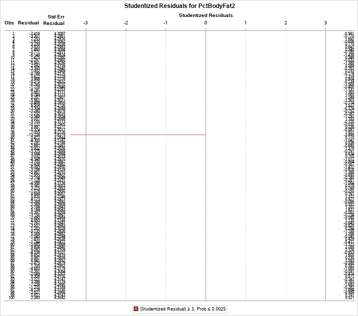

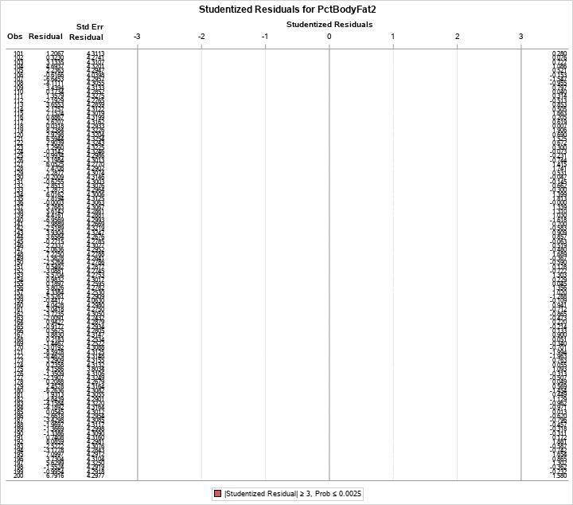

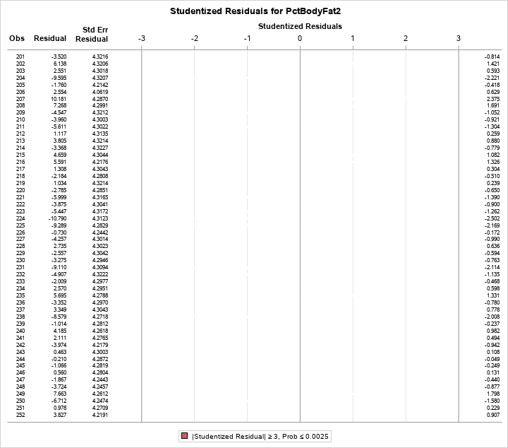

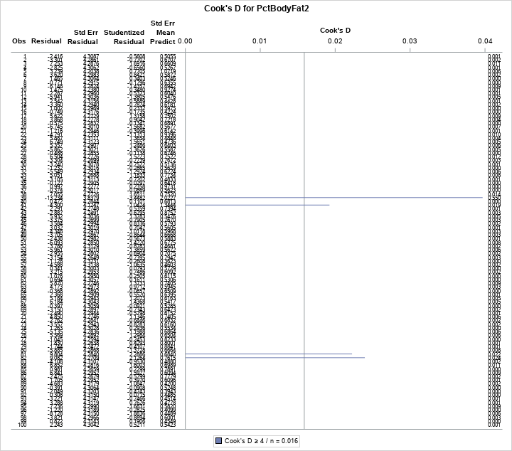

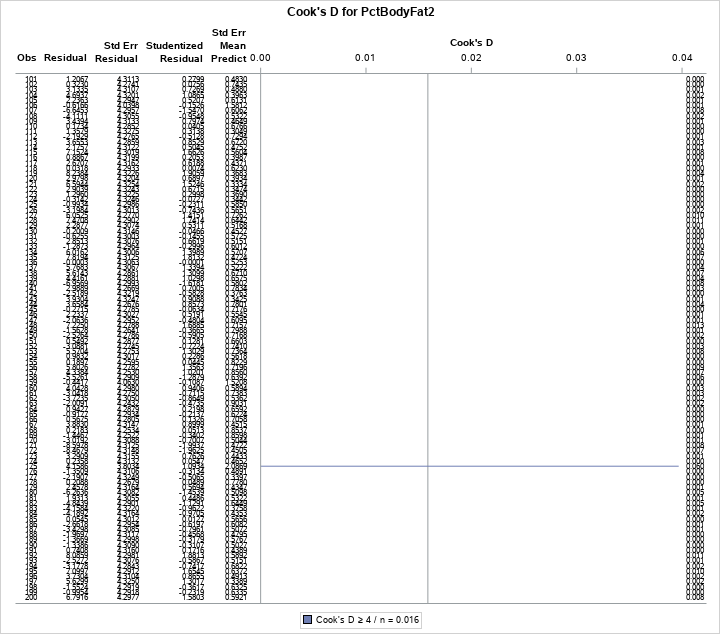

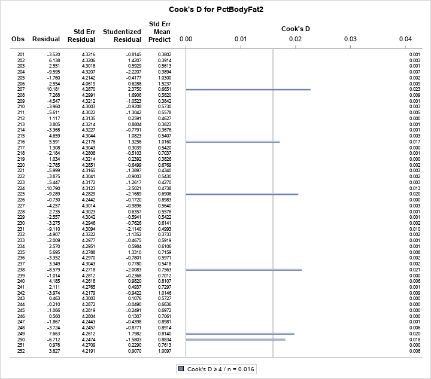

| Sum of Residuals | 1.53571 |
| --- | --- |
| Sum of Squared Residuals | 4629.84908 |
| Predicted Residual SS (PRESS) | 4942.90434 |

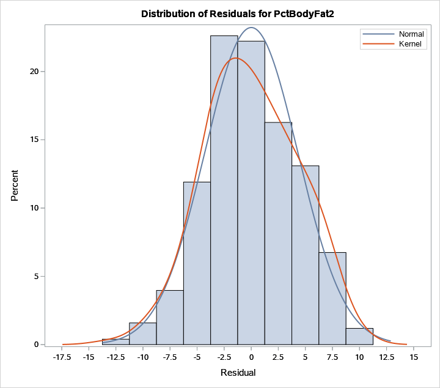

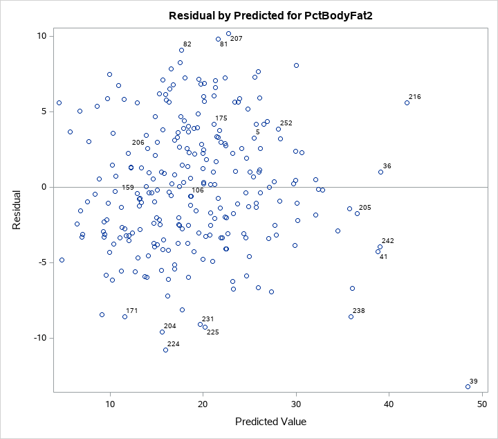

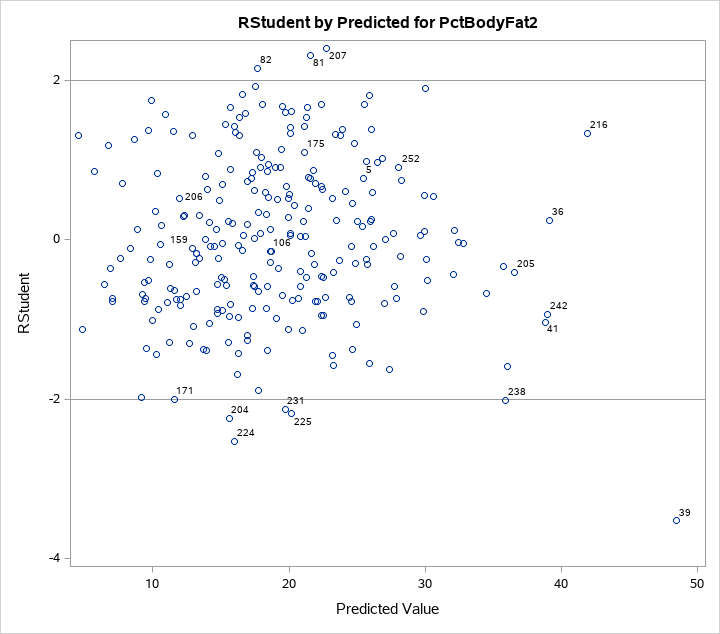

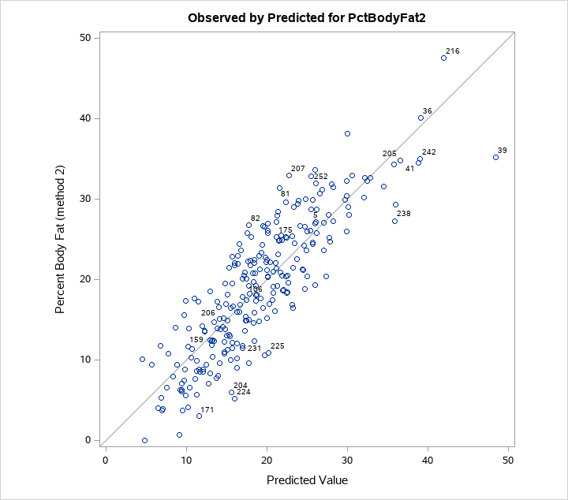

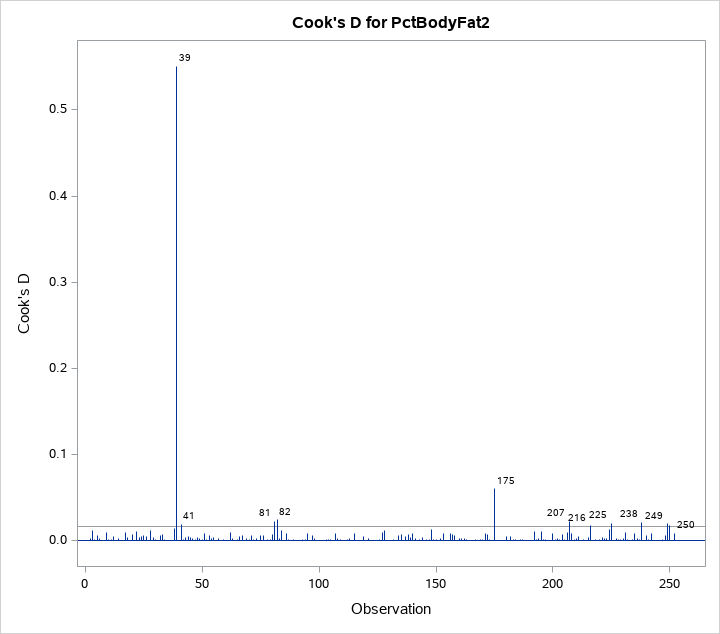

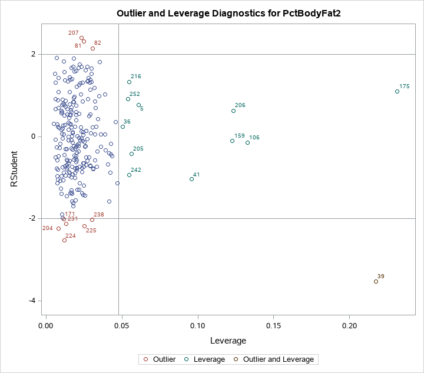

[21 more figures not shown]

```sas
ods exclude OutputStatistics;
proc reg data=pfolio.bodyfat
plots(maxpoints=none label unpack) = (diagnostics dffits dfbetas);
model pctbodyfat2 = age height neck abdomen
forearm wrist / noint ss2 influence partial r stb;
run;
quit;
```

**Visual Diagnostic**

- Both Residual distribution plot and residual qq plot are normally distributed
- The visual check of ObservedByPredicted graph has a diagonal line, which indicates that the model works
- Also in the residual Fit spread plot, the centred fitted values is taller than the residual values, which also concludes that spread of residual values is smaller than spread of the fitted values

**Model Equation** The above model can be expressed using equation:

pctbodyfat2 =

```
    +Age(0.08045)
    +Abdomen(0.76907)
    -Height(0.22919)
    -Neck(0.56594)
    -Wrist(1.82180)
    +Forearm(0.52952)
```